# Comparison of Hypertension Medication Prices

Chetna Jhurani

March 22, 2018

# Introduction

Hypertension is a rising problem in the United States. According to the CDC, almost one in every three Americans is diagnosed with hypertension, and this number shows no signs of decreasing. Hypertension can often lead to heart disease or stroke, two of the leading causes of death in the United States. Seen here: https://www.cdc.gov/bloodpressure/faqs.htm

As such, there are many different types of hypertension medications that have many different methods of action ranging from simply decreasing blood volume (diuretics) to dilating blood vessels. The most common types of hypertension medications are diuretics, angiotensin-converting enzyme (ACE) inhibitors, angiotensin II receptor blockers (ARBs), and calcium channel blockers (CCBs). However, the most frequently prescribed medications may not necessarily be as affordable as those that are less frequently prescribed. The main question to focus on is: How can access/affordability of hypertension medication be increased? Programs such as Medicaid increase access to these medications, so the focus will be on Medicaid coverage of certain hypertension medications.

# Deeper Dive into the Dataset

## Important fields and information

The original data set comes from the December 2017 Federal Upper Limits provided on the Medicaid website seen here: https://data.medicaid.gov/Drug-Pricing-and-Payment/Federal-Upper-Limits-2017-12/3usn-qyfh/data. The most important information in the data set is the manufacturing cost and the cost covered by Medicaid. These columns provided the quantitative data that is needed for further data analysis. After wrangling this data, information on which drugs were hypertension medications as well as the method of action of the specific drug was still needed. The dataset was wrangled further with the information provided by the Mayo Clinic website, which can be seen here: https://www.mayoclinic.org/diseases-conditions/high-blood-pressure/diagnosis-treatment/drc-20373417. Not only did it provide the most common hypertension medications, but it gave their method of action as well. Finally, in order to include a quantitative comparison on the most common medications, information on how often each type of hypertension medication was prescribed was also needed. This additional data came from the statistics listed by the NCBI study seen here https://www.ncbi.nlm.nih.gov/pmc/articles/PMC4808570/ and was added to the wrangled data set.

## Cleaning and Wrangling

As previously stated, the initial dataset started out as the Federal Upper Limits (FUL) table, was wrangled and then added information from the Mayo Clinic and the NCBI study was added. There was a lot of extraneous information provided in the FUL table such as the item code number(NDC). Often times, the same medication was listed multiple times with only a different NDC, so this column was removed from the data. Since all of the data was from December 2017, the “Year” and “Month” columns were also removed. Additional columns that were irrelevant were renamed and removed as well. Once all this was done, the “distinct” function was used to remove all the duplicate rows. What was left in the end was ingredient name, strength, dosage, coverage, and manufacturing price.

Now that there was only one row for each drug, a column for the method of action of each drug (Type) was added and filled with the appropriate information. Then another column was created for the pure substances and filled that with the appropriate information as well. However, the dataset still contained every single drug covered by Medicaid, when only the hypertension medications were needed. As a result, the types of hypertension medications were saved in one variable (“Types”) and filtered out the rows that did not contain the specified types of hypertension medications.

The code can be seen here: https://github.com/cjhurani2000/Capstone-Project/blob/master/data%20wrangling.R

The final table is below.

Table 1. Coverage Data

| X1 | Ingredient | Strength | Dosage | AMPs | Full | Paid | PPMG | Type | Pure |
| --- | --- | --- | --- | --- | --- | --- | --- | --- | --- |
| 1 | ACEBUTOLOL HYDROCHLORIDE | 200 | CAPSULE | 0.134564 | 0.235487 | 0.100923 | 0.0005046 | beta blocker | N |
| 2 | ATENOLOL | 100 | TABLET | 0.079799 | 0.139648 | 0.059849 | 0.0005985 | beta blocker | Y |
| 3 | CAPTOPRIL | 100 | TABLET | 0.580250 | 1.777050 | 1.196800 | 0.0119680 | ACE inhibitor | Y |
| 4 | HYDROCHLOROTHIAZIDE | 25 | TABLET | 0.003227 | 0.009900 | 0.006673 | 0.0002669 | diuretic | Y |
| 5 | LISINOPRIL | 40 | TABLET | 0.031287 | 0.054752 | 0.023465 | 0.0005866 | ACE inhibitor | Y |
| 6 | DILTIAZEM HYDROCHLORIDE | 360 | CAPSULE, EXTENDED RELEASE | 0.333229 | 0.616180 | 0.282951 | 0.0007860 | CCB | N |
| 7 | BENAZEPRIL HYDROCHLORIDE | 40 | TABLET | 0.029580 | 0.059590 | 0.030010 | 0.0007503 | ACE inhibitor | N |
| 8 | AMLODIPINE BESYLATE | 10 | TABLET | 0.019519 | 0.034158 | 0.014639 | 0.0014639 | CCB | N |
| 9 | LOSARTAN POTASSIUM | 100 | TABLET | 0.038030 | 0.066553 | 0.028523 | 0.0002852 | ARB | N |
| 10 | CANDESARTAN CILEXETIL | 32 | TABLET | 1.190418 | 2.083232 | 0.892814 | 0.0279004 | ARB | N |

# Preliminary Analysis

The best method of action following the wrangling of the data was to look at the data graphically with each drug listed individually. The price is listed per gram rather than by milligram so that the difference in pricing is clearer.

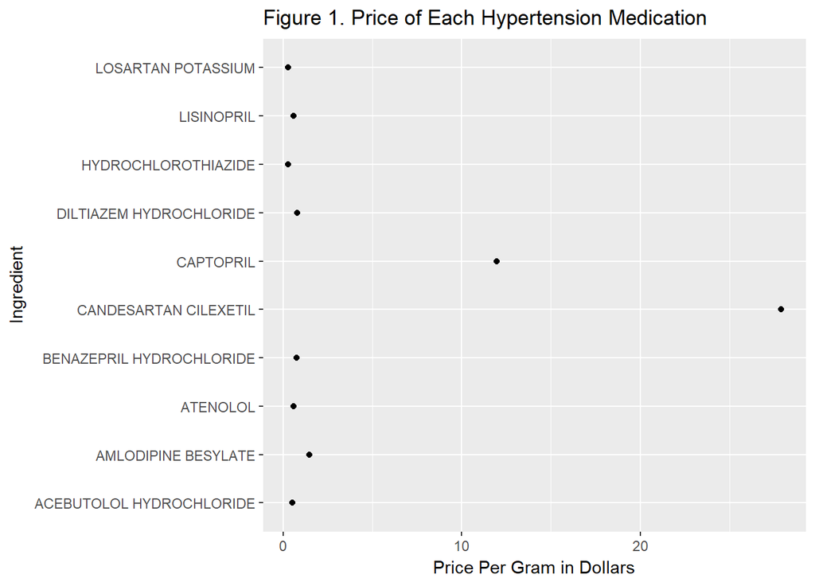

Visually, Captopril and Candesartan Cilexetil were the most expensive. In order to determine what factors contributed to this, the analysis was taken a step further. From here on, the focus was on comparing the method of action of the drug (Type) and the purity of the substance with the price (PPMG). Before graphing these comparisons, a summary statistic was still needed. Based on the limited data, the statistic chosen was the mean.

```r
cov_type <- coverage_clean %>%
  group_by(Type) %>%
  summarize(mean_PPMG = mean(PPMG)) %>%
  arrange(mean_PPMG)

cov_pure <- coverage_clean %>%
  group_by(Pure) %>%
  summarize(mean_PPMG = mean(PPMG)) %>%
  arrange (mean_PPMG)
```

The graphs using the above statistics can be seen below.

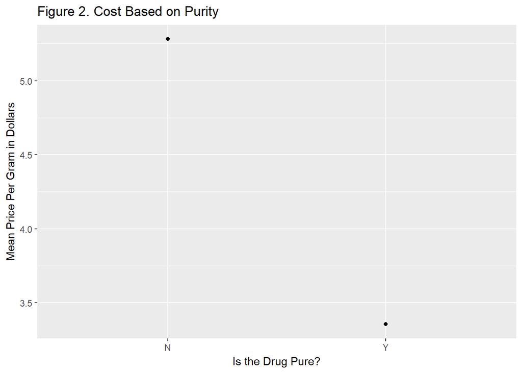

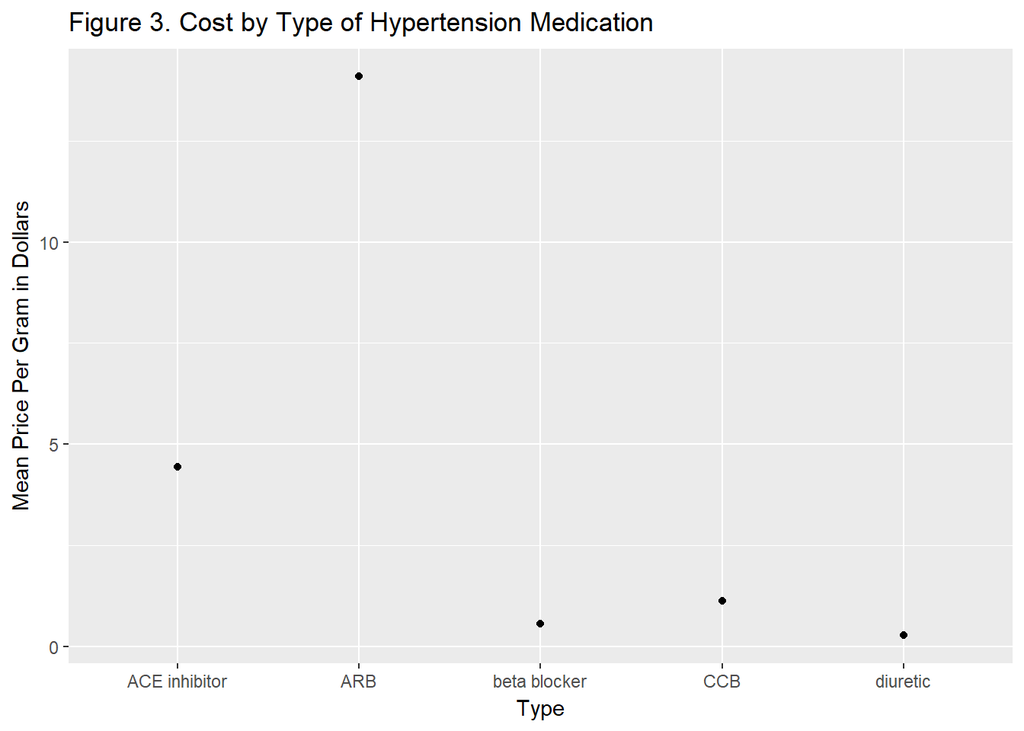

## What This Means

Visually, there is an obvious difference in the price paid for the pure substances versus the ones that are not. This makes sense, as combining two drugs will obviously cost more than one simple drug. This information by itself may not be so useful. However, when examining the data further, it may explain any apparent skew in the data. Looking at the specific types of hypertension medications, ARBs are noticeably the most expensive. At this point, only scatterplots have been included as the data is not only limited, but it is also primarily qualitative. While the cost of ARBs may have been skewed by the impure Candesartan Cilexetil, it may be of interest to know what contributed to the cost of each type of hypertension medication.

# Further Analysis

## Introducing a New Variable/Further Wrangling

So far, only the qualitative data, apart from the PPMG, has been examined. In order to not only introduce a quantitative variable, but to also further examine the types of medications, a new variable was introduced: frequency. This variable comes from the aforementioned NCBI study that contains information on how often each type of medication is prescribed. The introduction of this new variable allows the problem to be framed as a supervised regression machine learning problem: How does the frequency a medication is prescribed correlate with its price?

To do this, the coverage data from **Table 1** was wrangled even further. Once again, medications were grouped by type, summarized by the mean summary statistic, and were saved in a new table. Then, a column was added for the frequency and was filled in with the values corresponding with those listed in the NCBI article. The frequency refers to the proportion of patients with hypertension that were prescribed a certain medication.

The code can be found here: https://github.com/cjhurani2000/Capstone-Project/blob/master/frequency.R

The resulting table can be seen below.

Table 2. Prescription Frequency

| X1 | Type | Mean_PPMG | Frequency |
| --- | --- | --- | --- |
| 1 | ACE inhibitor | 0.0044350 | 0.1679 |
| 2 | ARB | 0.0140928 | 0.3357 |
| 3 | beta blocker | 0.0005516 | 0.1363 |
| 4 | CCB | 0.0011249 | 0.1191 |
| 5 | diuretic | 0.0002669 | 0.1990 |

## Machine Learning

First, let’s look at this data visually in a scatterplot.

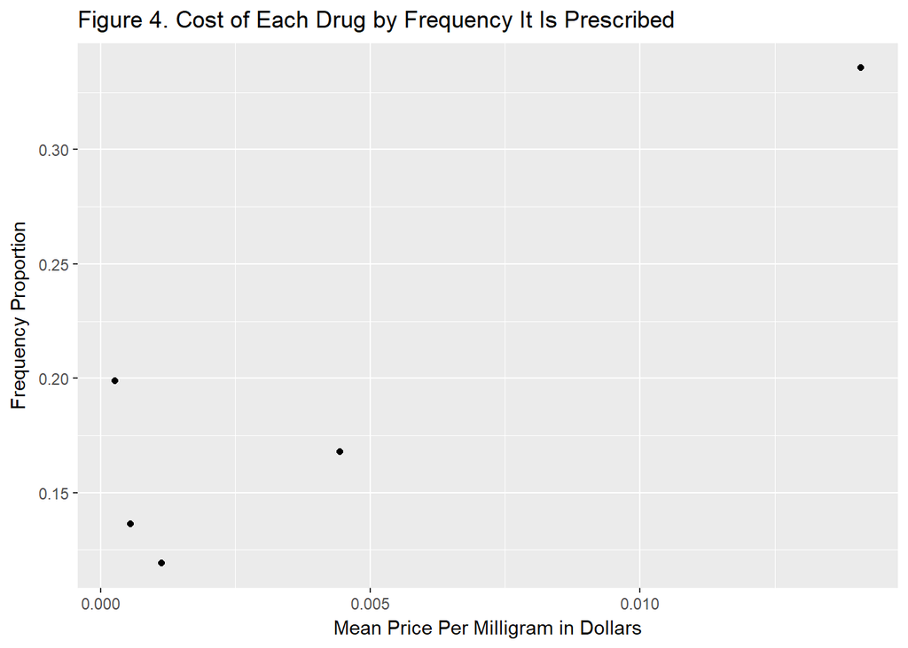

Based on this scatterplot, the best way to proceed from here is to use a linear regression model using the code below.

```r
#linear regression model
freq.mod <- lm(Frequency ~ Mean_PPMG, data=freq_cov)

#summarize results
summary(freq.mod)
```

```
##
## Call:
## lm(formula = Frequency ~ Mean_PPMG, data = freq_cov)
##
## Residuals:
##         1         2         3         4         5
## -0.028245  0.010722 -0.008042 -0.032890  0.058455
##
## Coefficients:
##             Estimate Std. Error t value Pr(>|t|)
## (Intercept)  0.13698    0.02429   5.640   0.0110 *
## Mean_PPMG   13.33972    3.66222   3.643   0.0357 *
## ---
## Signif. codes:  0 '***' 0.001 '**' 0.01 '*' 0.05 '.' 0.1 ' ' 1
##
## Residual standard error: 0.04272 on 3 degrees of freedom
## Multiple R-squared:  0.8156, Adjusted R-squared:  0.7541
## F-statistic: 13.27 on 1 and 3 DF,  p-value: 0.03568
```

```r
#significance
anova(freq.mod)
```

```
## Analysis of Variance Table
##
## Response: Frequency
##           Df    Sum Sq   Mean Sq F value  Pr(>F)
## Mean_PPMG  1 0.0242194 0.0242194  13.268 0.03568 *
## Residuals  3 0.0054762 0.0018254
## ---
## Signif. codes:  0 '***' 0.001 '**' 0.01 '*' 0.05 '.' 0.1 ' ' 1
```